# Cardio Fitness Project

### Description

#### Objective

Explore the dataset to identify differences between the customers of each product. You can also explore relationships between the different attributes of the customers. You can approach it from any other line of questioning that you feel could be relevant for the business. The idea is to get you comfortable working in Python.

You are expected to do the following :

Come up with a customer profile (characteristics of a customer) of the different products Perform univariate and multivariate analyses Generate a set of insights and recommendations that will help the company in targeting new customers.

#### Dataset

- CardioGoodFitness.csv

#### Data Dictionary

The data is about customers of the treadmill product(s) of a retail store called Cardio Good Fitness. It contains the following variables-

- Product - The model no. of the treadmill
- Age - Age of the customer in no of years
- Gender - Gender of the customer
- Education - Education of the customer in no. of years
- Marital Status - Marital status of the customer
- Usage - Avg. # times the customer wants to use the treadmill every week
- Fitness - Self rated fitness score of the customer (5 - very fit, 1 - very unfit)
- Income - Income of the customer
- Miles- Miles that a customer expects to run

### Import the necessary packages - pandas, numpy, seaborn, matplotlib.pyplot

```python
import pandas as pd
import matplotlib.pyplot as plt
import seaborn as sns
import warnings
warnings.filterwarnings("ignore")
```

### Read in the dataset

```python
#read csv data using pandas.
cardio_data = pd.read_csv('CardioGoodFitness.csv')
```

### Check the dataset

```python
cardio_data.head()
```

|  | Product | Age | Gender | Education | MaritalStatus | Usage | Fitness | Income | Miles |
| --- | --- | --- | --- | --- | --- | --- | --- | --- | --- |
| 0 | TM195 | 18 | Male | 14 | Single | 3 | 4 | 29562 | 112 |
| 1 | TM195 | 19 | Male | 15 | Single | 2 | 3 | 31836 | 75 |
| 2 | TM195 | 19 | Female | 14 | Partnered | 4 | 3 | 30699 | 66 |
| 3 | TM195 | 19 | Male | 12 | Single | 3 | 3 | 32973 | 85 |
| 4 | TM195 | 20 | Male | 13 | Partnered | 4 | 2 | 35247 | 47 |

### Understanding the structure of the data

- Overview of the dataset shape, datatypes - Statistical summary and check for missing values

```python
#dataset shape
cardio_data.shape
```

```
(180, 9)
```

```python
#datatypes
cardio_data.dtypes
```

```
Product          object
Age               int64
Gender           object
Education         int64
MaritalStatus    object
Usage             int64
Fitness           int64
Income            int64
Miles             int64
dtype: object
```

```python
cardio_data.info() # concise summary of a DataFrame.
```

```
<class 'pandas.core.frame.DataFrame'>
RangeIndex: 180 entries, 0 to 179
Data columns (total 9 columns):
 #   Column         Non-Null Count  Dtype
---  ------         --------------  -----
 0   Product        180 non-null    object
 1   Age            180 non-null    int64
 2   Gender         180 non-null    object
 3   Education      180 non-null    int64
 4   MaritalStatus  180 non-null    object
 5   Usage          180 non-null    int64
 6   Fitness        180 non-null    int64
 7   Income         180 non-null    int64
 8   Miles          180 non-null    int64
dtypes: int64(6), object(3)
memory usage: 12.8+ KB
```

```python
# Statistical Summary
cardio_data.describe()
```

|  | Age | Education | Usage | Fitness | Income | Miles |
| --- | --- | --- | --- | --- | --- | --- |
| count | 180.000000 | 180.000000 | 180.000000 | 180.000000 | 180.000000 | 180.000000 |
| mean | 28.788889 | 15.572222 | 3.455556 | 3.311111 | 53719.577778 | 103.194444 |
| std | 6.943498 | 1.617055 | 1.084797 | 0.958869 | 16506.684226 | 51.863605 |
| min | 18.000000 | 12.000000 | 2.000000 | 1.000000 | 29562.000000 | 21.000000 |
| 25% | 24.000000 | 14.000000 | 3.000000 | 3.000000 | 44058.750000 | 66.000000 |
| 50% | 26.000000 | 16.000000 | 3.000000 | 3.000000 | 50596.500000 | 94.000000 |
| 75% | 33.000000 | 16.000000 | 4.000000 | 4.000000 | 58668.000000 | 114.750000 |
| max | 50.000000 | 21.000000 | 7.000000 | 5.000000 | 104581.000000 | 360.000000 |

```python
# Check for missing values
cardio_data.isnull().sum()
```

```
Product          0
Age              0
Gender           0
Education        0
MaritalStatus    0
Usage            0
Fitness          0
Income           0
Miles            0
dtype: int64
```

```python
average_profile_by_gender_income = cardio_data.groupby(['Gender','Product'])['Income'].mean().sort_values(ascending=False).reset_index()
display(average_profile_by_gender_income)
```

|  | Gender | Product | Income |
| --- | --- | --- | --- |
| 0 | Male | TM798 | 75825.030303 |
| 1 | Female | TM798 | 73633.857143 |
| 2 | Female | TM498 | 49336.448276 |
| 3 | Male | TM498 | 48634.258065 |
| 4 | Male | TM195 | 46815.975000 |
| 5 | Female | TM195 | 46020.075000 |

## Univariate Data Analysis

### Analysis of spread and distribution of every feature in the dataset.

- Graphs and analyses using histogram, distplot, scatterplot, correlation, heatmap, scatter plot, pairplot, jointplot, count plot etc

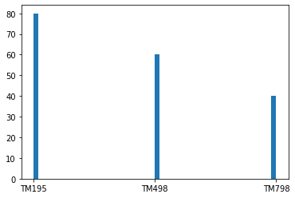

```python
#histogram for product
plt.hist(cardio_data['Product'], bins=50)
plt.show()
```

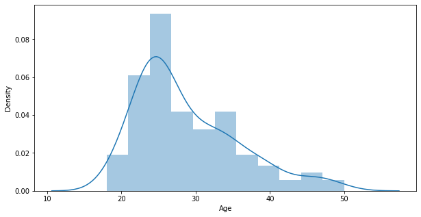

```python
#dist plot histogram on age
plt.figure(figsize=(10,5))
sns.distplot(cardio_data['Age'], hist=True)
```

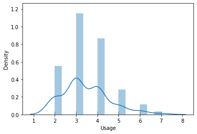

```python
#dist plot histogram on usage
sns.distplot(cardio_data['Usage'], hist=True,rug=True)
```

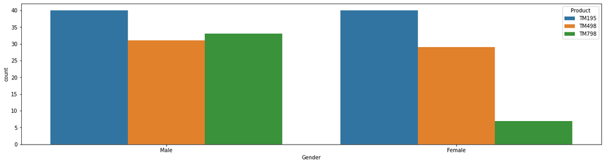

```python
plt.figure(figsize=(20,5))
sns.countplot(x='Gender', hue='Product', data=cardio_data)
```

- Count plot - female did not buy TM798 much

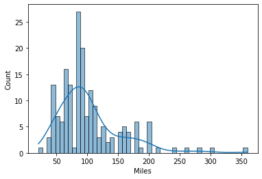

```python
sns.histplot(cardio_data['Miles'], bins=50,kde=True,legend=True)
plt.show()
```

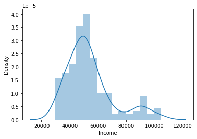

```python
#dist plot histogram on age
sns.distplot(cardio_data['Income'], hist=True,kde=True)
plt.show()
```

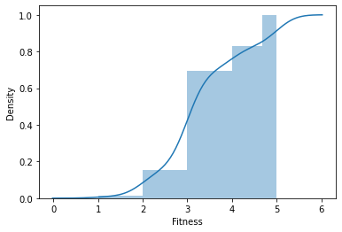

```python
sns.distplot(cardio_data['Fitness'], hist_kws=dict(cumulative=True), kde_kws=dict(cumulative=True))
plt.show()
```

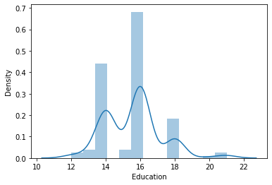

```python
sns.distplot(cardio_data['Education'])
plt.show()
```

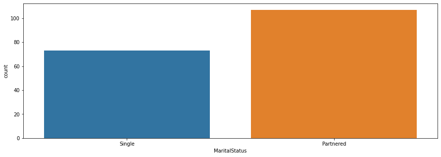

```python
plt.figure(figsize=(15,5))
sns.countplot(x='MaritalStatus', data=cardio_data)
plt.show()
```

- Partnered people are more customers

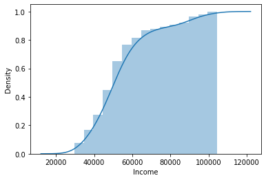

```python
sns.distplot(cardio_data['Income'], hist_kws=dict(cumulative=True), kde_kws=dict(cumulative=True))
plt.show()
```

## Multivariate Data Analysis

### Analysis of interaction between features, in the dataset

```python
#corelation
correlation=cardio_data.corr()
correlation
```

|  | Age | Education | Usage | Fitness | Income | Miles |
| --- | --- | --- | --- | --- | --- | --- |
| Age | 1.000000 | 0.280496 | 0.015064 | 0.061105 | 0.513414 | 0.036618 |
| Education | 0.280496 | 1.000000 | 0.395155 | 0.410581 | 0.625827 | 0.307284 |
| Usage | 0.015064 | 0.395155 | 1.000000 | 0.668606 | 0.519537 | 0.759130 |
| Fitness | 0.061105 | 0.410581 | 0.668606 | 1.000000 | 0.535005 | 0.785702 |
| Income | 0.513414 | 0.625827 | 0.519537 | 0.535005 | 1.000000 | 0.543473 |
| Miles | 0.036618 | 0.307284 | 0.759130 | 0.785702 | 0.543473 | 1.000000 |

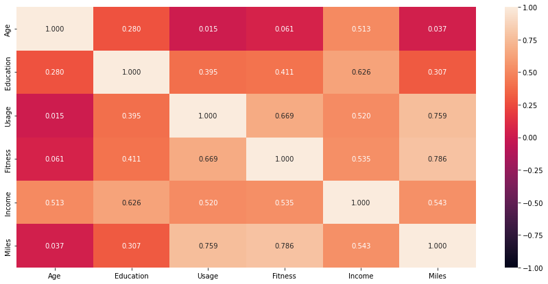

```python
plt.figure(figsize=(15, 7))
sns.heatmap(correlation, annot=True, vmin=-1, vmax=1, fmt=".3f")
plt.show()
```

```python
cardio_data.Product = cardio_data.Product.astype('category')
cardio_data.Gender = cardio_data.Gender.astype('category')
cardio_data.MaritalStatus = cardio_data.MaritalStatus.astype('category')
```

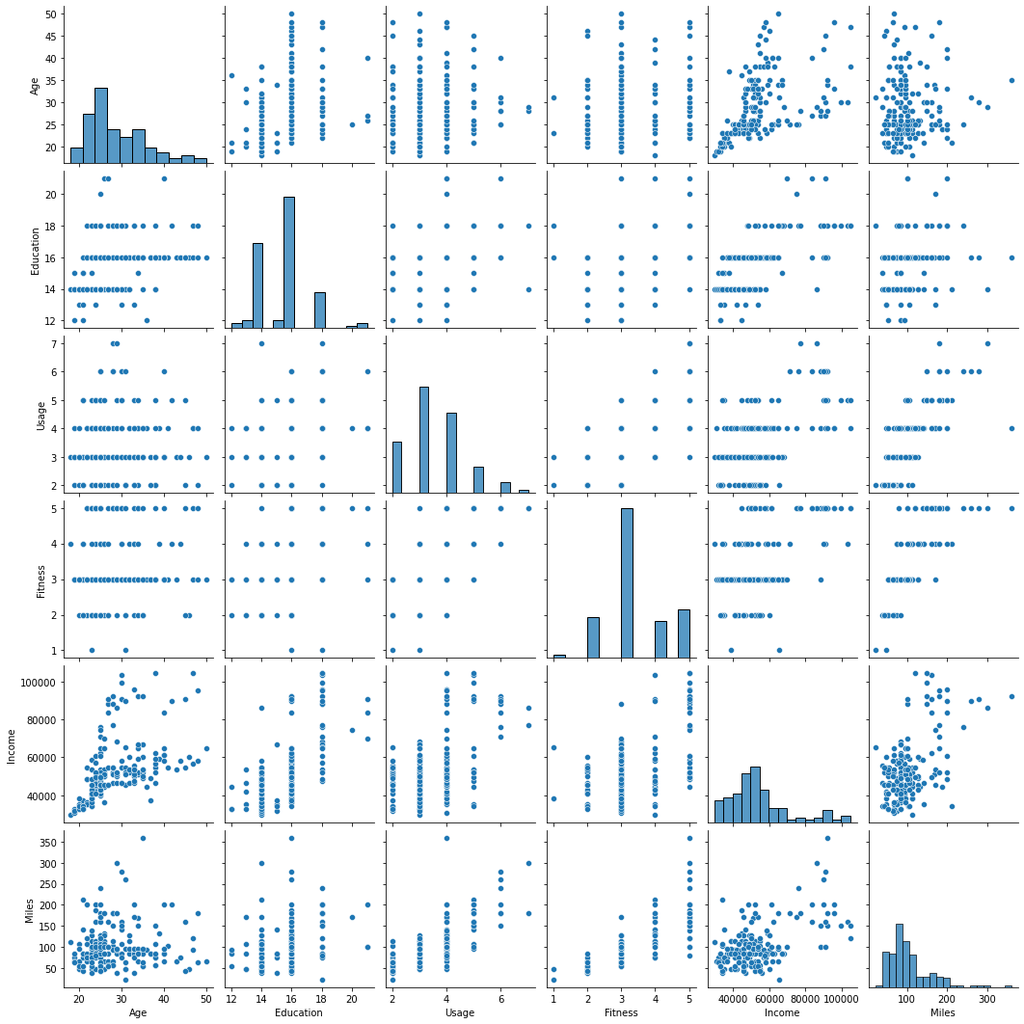

```python
sns.pairplot(cardio_data)
plt.show()
```

```python
cardio_data.dtypes #Tranforming objects to categorical variables for analysis
```

```
Product          category
Age                 int64
Gender           category
Education           int64
MaritalStatus    category
Usage               int64
Fitness             int64
Income              int64
Miles               int64
dtype: object
```

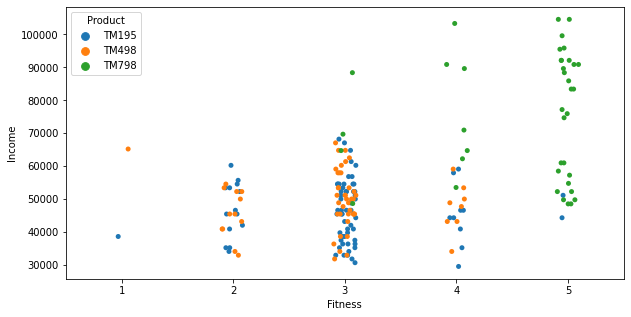

```python
plt.figure(figsize=(10,5))
sns.stripplot(x='Fitness', y='Income', data=cardio_data, hue='Product')
plt.show()
```

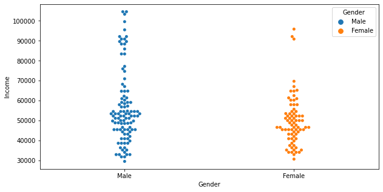

```python
plt.figure(figsize=(10,5))
sns.swarmplot(x='Gender', y='Income', data=cardio_data,hue='Gender')
plt.show()
```

- Females have less income

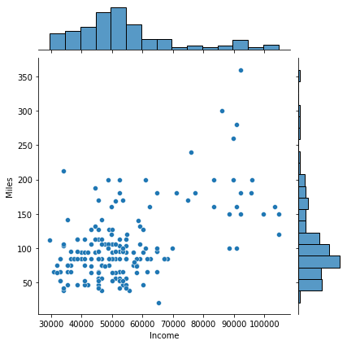

```python
sns.jointplot(data = cardio_data, x = 'Income', y = 'Miles');
```

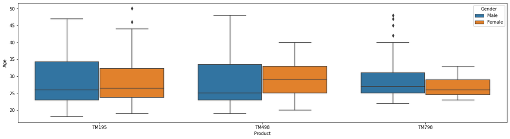

```python
plt.figure(figsize=(20,5))
sns.boxplot(x='Product', y='Age', data=cardio_data, hue='Gender')
plt.show()
```

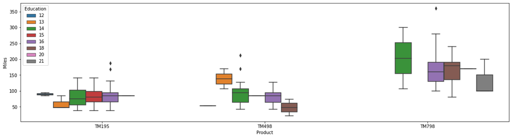

```python
plt.figure(figsize=(20,5))
sns.boxplot(x='Product', y='Miles', data=cardio_data, hue='Education')
plt.show()
```

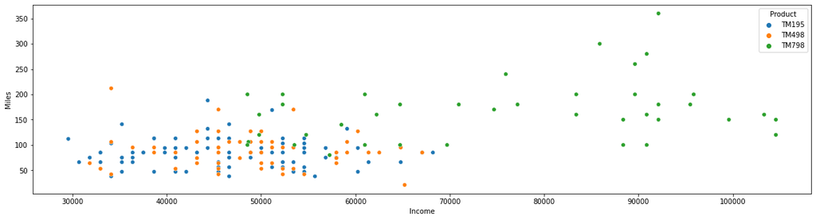

```python
plt.figure(figsize=(20,5))
sns.scatterplot(x='Income', y='Miles', data=cardio_data, hue='Product')
plt.show()
```

- People with higher incomes buy TM798

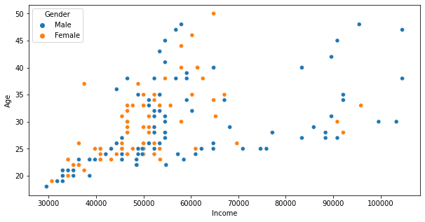

```python
plt.figure(figsize=(10,5))
sns.scatterplot(x='Income', y='Age', data=cardio_data, hue='Gender')
plt.show()
```

- Most females customers have less than 70k income

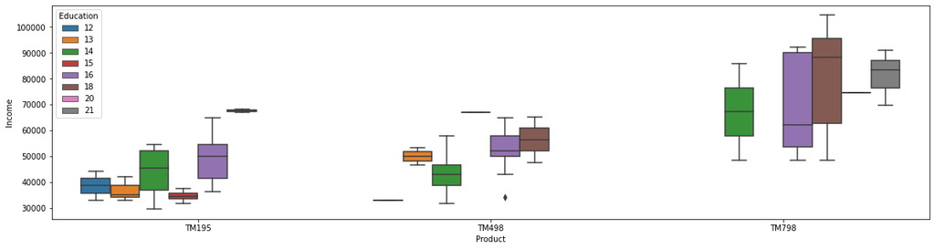

```python
plt.figure(figsize=(20,5))
sns.boxplot(x='Product', y='Income', data=cardio_data, hue='Education')
```

- box plot quartiles show most TM798 customers have higher incomes and education

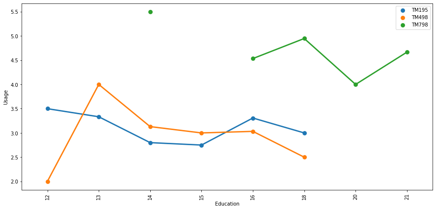

```python
plt.figure(figsize=(15, 7)) # To resize the plot
sns.pointplot(x='Education', y='Usage', data=cardio_data, ci=None, hue = 'Product')
plt.legend(bbox_to_anchor=(1, 1))
plt.xticks(rotation=90) # To rotate the x axis labls
plt.show()
```

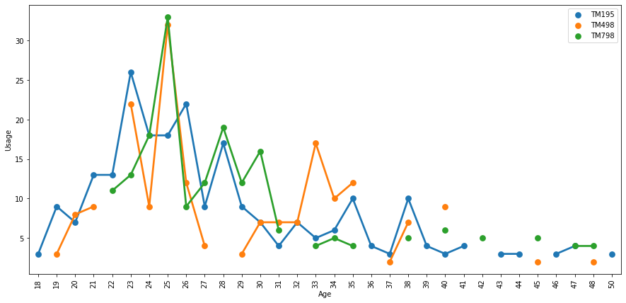

```python
plt.figure(figsize=(15, 7)) # To resize the plot
sns.pointplot(x='Age', y='Usage', data=cardio_data, estimator=sum, ci=None, hue = 'Product')
plt.legend(bbox_to_anchor=(1, 1))
plt.xticks(rotation=90)
plt.show()
```

- people from age 23 to 27 seem to have usage more

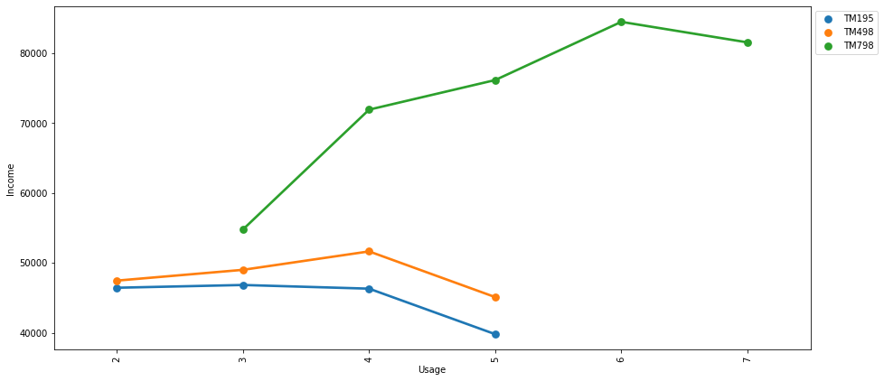

```python
plt.figure(figsize=(15, 7)) # To resize the plot
sns.pointplot(x='Usage', y='Income', data=cardio_data, ci=None, hue = 'Product')
plt.legend(bbox_to_anchor=(1, 1))
plt.xticks(rotation=90) # To rotate the x axis labls
plt.show()
```

- TM798 tend to use atleast 3 times a week

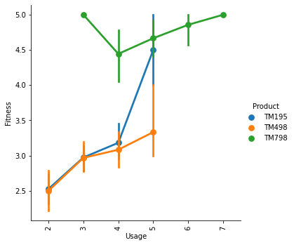

```python
plt.figure(figsize=(20, 20)) # To resize the plot
cplot1=sns.catplot(y='Fitness', x='Usage',
            data=cardio_data,
            hue="Product",kind='point'
               )
cplot1.set_xticklabels(rotation=90)
plt.show()
```

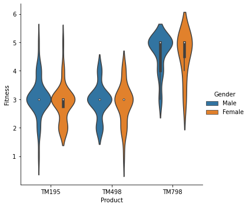

```python
# plt.figure(figsize=(20, 20)) # To resize the plot
cplot1=sns.catplot(y='Fitness', x='Product',
            data=cardio_data,
            hue="Gender",kind='violin'
               )
cplot1.set_xticklabels(rotation=0)
plt.show()
```

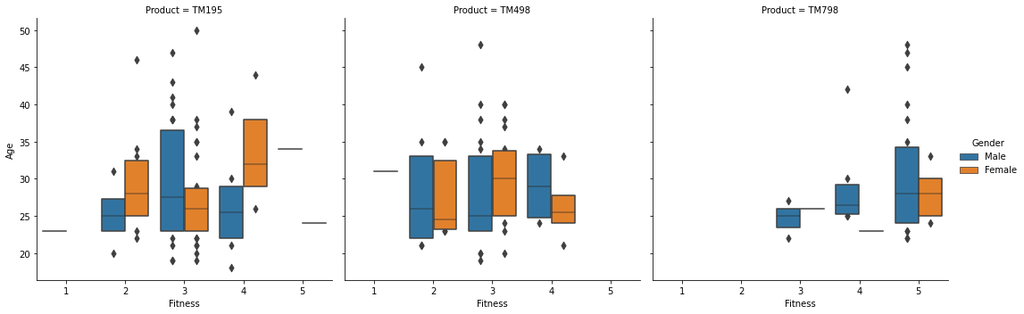

```python
# plt.figure(figsize=(20, 20)) # To resize the plot
cplot1=sns.catplot(y='Age', x='Fitness',
            data=cardio_data,col='Product',
            hue="Gender",kind='boxen'
               )
# cplot1.set_xticklabels(rotation=90)
plt.show()
```

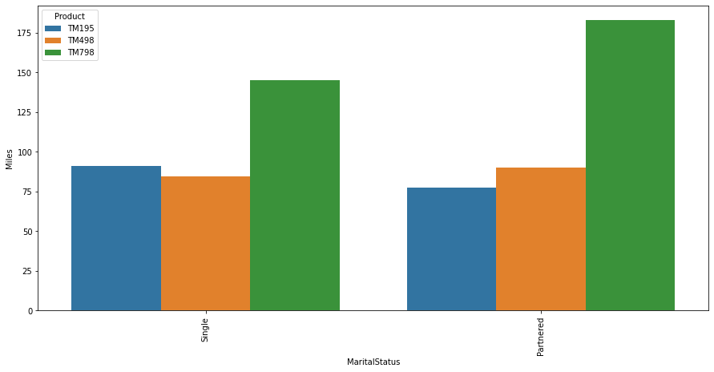

```python
plt.figure(figsize=(15, 7)) # To resize the plot
sns.barplot(data = cardio_data, y = "Miles", x = "MaritalStatus", hue='Product', ci=None,)
plt.xticks(rotation=90) # To rotate the x axis lables
plt.show()
```

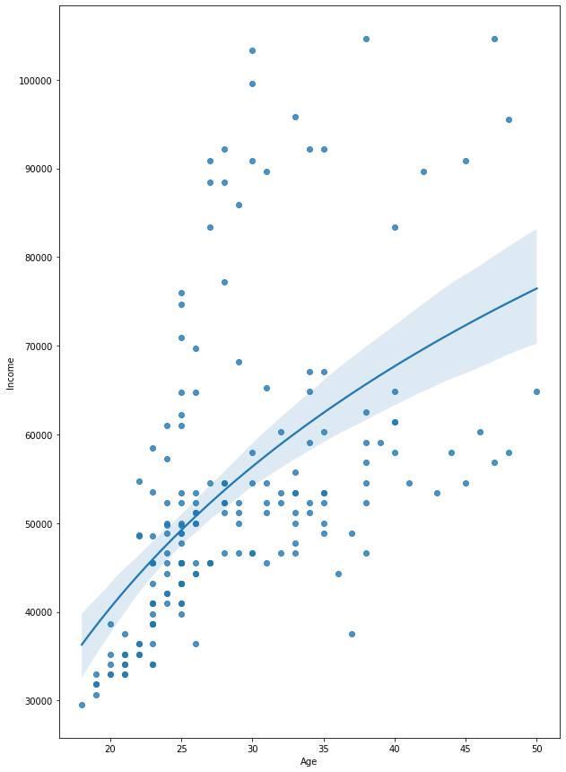

```python
figure = plt.figure(figsize=(10,15))
#regression plot age vs income
ax = sns.regplot(x='Age',y='Income',data=cardio_data, logx=True)
```

- Income increases with age and plateaus later

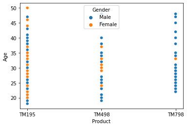

```python
sns.scatterplot(cardio_data['Product'], cardio_data['Age'], hue=cardio_data['Gender'])  # Plots the scatter plot using two variables
```

- More Males buy the TM798 product. There are more mix in other TM195, TM498 product lines

### Conclusion and Recommendations

#### Recommendation for customer profiling:

- TM798: Target Male users with income greater than 70,000 within age range of 25-35 years and having education of 15+ years with TM798 product. Marketing should target females with higher income. Fitness programs can be introduced to maintain strong customer retention as the focus of this user group is fitness and they are frequent and regular users. TM798 is the premium pricer product supposedly. Improve product for new opportunities is to analyze female interest. Marital Status is more likely to purchase.
- TM195: Target both male and female users with income greater than 30,000 and less than 60,000 within age range of 25-35 years with TM195,TM498 product. User engagement for usage, miles, fitness is lesser compared to premium product TM798 group. Since this is the biggest share of product sales. Explore if any workout program features in TM798 can also be introduced in TM195 to improve customer experience, weekly usage, miles and fitness of its users maintaining the same price/income group targeting.

### Thank you - Amogh Antarkar